# Fruits_classifier

## Introduction to programming and data visualisation

Dataset 1 (the dataset was uploaded on Blackboard: 'dataProblem1.csv')

Your company was asked to devise a machine learning model that can classify fruit based on quantitative features, such as weight and size. Your managed asked you to build a preliminary model that can classify apple vs. non-apple on a small example dataset. The dataset has about 400 entries including apples, oranges, and lemons. The columns of the dataset indicate the class of the entry (apple, orange, or lemon), the weight, width, length, and a colour-score which is an unspecified value indicating the colour of the fruit.

- Task 1 (25 points out of 100): Study the dataset. Visualise the data (e.g., using scatterplots). Try different combinations of features on the x-axis and y-axis. Different colours or markers should be used for different classes (e.g., apple vs. non-apple). The purpose of this task is to understand the dataset (e.g., is everything as expected?) and to discuss this with your manager. To do so, produce the plots and explain the meaning of the figures in plain English.
- Task 2 (30 points out of 100): Fit a binary classifier and quantify its accuracy. Visualise the classification results as we discussed in the lectures and tutorials. In addition, add a short description in plain English (e.g., by using the Python comments) to each numerical result, explaining what that value represents and what can be concluded from the analysis.
- Task 3 (10 points out of 100): Fit a 3-class classifier for apples vs. oranges vs. lemons and quantify the classification accuracy. As in task 2, please discuss the result in plain English.

Note: Remember that there may be many answers! You will be evaluated based on both your code and your understanding of the problem. Be curious! What would you tell to your manager? Can the dataset be improved? How?

```python
# Importing libraries
import numpy as np
import pandas as pd
import matplotlib.pyplot as plt

#Classifiers
from sklearn.neighbors import KNeighborsClassifier
from sklearn.svm import SVC
from sklearn.gaussian_process import GaussianProcessClassifier
from sklearn.gaussian_process.kernels import RBF
from sklearn.tree import DecisionTreeClassifier
from sklearn.ensemble import RandomForestClassifier
from sklearn.naive_bayes import GaussianNB
from sklearn.model_selection import train_test_split
from sklearn.metrics import ConfusionMatrixDisplay
```

#### Task 1

```python
# TODO
URL = "/Users/yana/Documents/01_TRINITY/02_Machine Learning/01_Homework01/dataProblem1.csv"
dataset = pd.read_csv(URL)
dataset.head()
```

|  | fruit_label | fruit_name | weight | width | height | color_score |
| --- | --- | --- | --- | --- | --- | --- |
| 0 | 1 | apple | 192 | 8.4 | 7.3 | 0.55 |
| 1 | 1 | apple | 180 | 8.0 | 6.8 | 0.59 |
| 2 | 1 | apple | 176 | 7.4 | 7.2 | 0.60 |
| 3 | 1 | apple | 178 | 7.1 | 7.8 | 0.92 |
| 4 | 1 | apple | 172 | 7.4 | 7.0 | 0.89 |

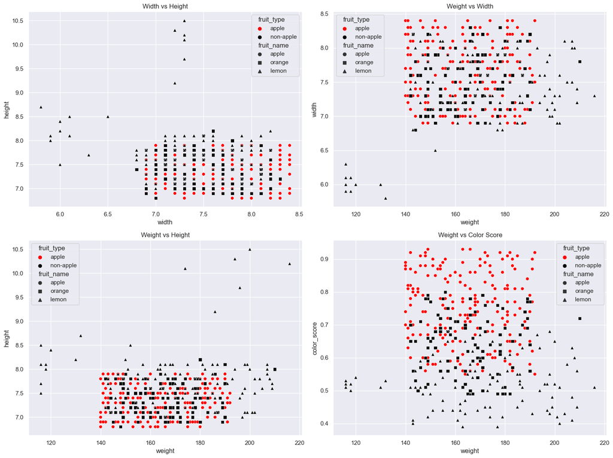

```python
# Visualising the dataset1 as apple and non-apple

import seaborn as sns
# Setting the style of seaborn
sns.set(style="darkgrid")

# Creating a new column in the dataset to classify fruits as 'apple' or 'non-apple'
dataset['fruit_type'] = dataset['fruit_name'].apply(lambda x: 'apple' if x == 'apple' else 'non-apple')

# Creating the color and marker maps for the new classification
color_map = {'apple': 'red', 'non-apple': 'black'}
# Updating the marker map to reflect individual fruit types again for detailed analysis
marker_map_individual = {'apple': 'o', 'orange': 's', 'lemon': '^'}  # Original fruit types

# Creating scatterplots with the different colors and marker maps
fig, axes = plt.subplots(2, 2, figsize=(16, 12))

# Width vs Height
sns.scatterplot(ax=axes[0, 0], data=dataset, x='width', y='height', hue='fruit_type', palette=color_map, style='fruit_name', markers=marker_map_individual)
axes[0, 0].set_title('Width vs Height')

# Weight vs Width
sns.scatterplot(ax=axes[0, 1], data=dataset, x='weight', y='width', hue='fruit_type', palette=color_map, style='fruit_name', markers=marker_map_individual)
axes[0, 1].set_title('Weight vs Width')

# Weight vs Height
sns.scatterplot(ax=axes[1, 0], data=dataset, x='weight', y='height', hue='fruit_type', palette=color_map, style='fruit_name', markers=marker_map_individual)
axes[1, 0].set_title('Weight vs Height')

# Weight vs Color Score
sns.scatterplot(ax=axes[1, 1], data=dataset, x='weight', y='color_score', hue='fruit_type', palette=color_map, style='fruit_name', markers=marker_map_individual)
axes[1, 1].set_title('Weight vs Color Score')

plt.tight_layout()
plt.show()
```